# ВиС (практикум) - домашно 1

## Божин Кацарски

ф.н. 81291, 24.04.2018

## Зад 1.

Разгледайте данните `Cars93` oт пакета `UsingR`

```r
install.packages("UsingR")
library("UsingR")
```

### а)

Определете марката на петте най-скъпи автомобила.

```r
carsByPrice <- Cars93[order(Cars93["Price"], decreasing=TRUE), ]
manufacturers <- carsByPrice[, "Manufacturer"]
top5 <- manufacturers[1:5]
top5
```

```
## [1] Mercedes-Benz Infiniti      Cadillac      Chevrolet     Audi
## 32 Levels: Acura Audi BMW Buick Cadillac Chevrolet Chrylser ... Volvo
```

### б)

Определете броя на цилиндрите на трите най-мощни спортни коли.

```r
sportyCars <- Cars93[Cars93["Type"]=="Sporty",]
byHP <- sportyCars[order(sportyCars["Horsepower"], decreasing=TRUE), ]
top3 <- byHP[1:3, ]
cylinders <- top3[, "Cylinders"]
cylinders
```

```
## [1] 8      6      rotary
## Levels: 3 4 5 6 8 rotary
```

### в)

Преизчислете разхода на автомобилите от мили за галон в литри за 100 км.

```r
carsNewFormat <- Cars93
carsNewFormat[, "MPG.city"] <- 282.48 / carsNewFormat[, "MPG.city"]
carsNewFormat[, "MPG.highway"] <- 282.48 / carsNewFormat[, "MPG.highway"]
colnames(carsNewFormat)[colnames(carsNewFormat) == "MPG.city"] <- "L/100km city"
colnames(carsNewFormat)[colnames(carsNewFormat) == "MPG.highway"] <- "L/100km highway"
carsNewFormat
```

|  | Manufacturer | Model | Type | Min.Price | Price | Max.Price | L/100km city | L/100km highway | AirBags | DriveTrain | Cylinders | EngineSize | Horsepower | RPM | Rev.per.mile | Man.trans.avail | Fuel.tank.capacity | Passengers | Length | Wheelbase | Width | Turn.circle | Rear.seat.room | Luggage.room | Weight | Origin | Make |
| --- | --- | --- | --- | --- | --- | --- | --- | --- | --- | --- | --- | --- | --- | --- | --- | --- | --- | --- | --- | --- | --- | --- | --- | --- | --- | --- | --- |
| 1 | Acura | Integra | Small | 12.9 | 15.9 | 18.8 | 11.299200 | 9.112258 | None | Front | 4 | 1.8 | 140 | 6300 | 2890 | Yes | 13.2 | 5 | 177 | 102 | 68 | 37 | 26.5 | 11 | 2705 | non-USA | Acura Integra |
| 2 | Acura | Legend | Midsize | 29.2 | 33.9 | 38.7 | 15.693333 | 11.299200 | Driver & Passenger | Front | 6 | 3.2 | 200 | 5500 | 2335 | Yes | 18.0 | 5 | 195 | 115 | 71 | 38 | 30.0 | 15 | 3560 | non-USA | Acura Legend |
| 3 | Audi | 90 | Compact | 25.9 | 29.1 | 32.3 | 14.124000 | 10.864615 | Driver only | Front | 6 | 2.8 | 172 | 5500 | 2280 | Yes | 16.9 | 5 | 180 | 102 | 67 | 37 | 28.0 | 14 | 3375 | non-USA | Audi 90 |
| 4 | Audi | 100 | Midsize | 30.8 | 37.7 | 44.6 | 14.867368 | 10.864615 | Driver & Passenger | Front | 6 | 2.8 | 172 | 5500 | 2535 | Yes | 21.1 | 6 | 193 | 106 | 70 | 37 | 31.0 | 17 | 3405 | non-USA | Audi 100 |
| 5 | BMW | 535i | Midsize | 23.7 | 30.0 | 36.2 | 12.840000 | 9.416000 | Driver only | Rear | 4 | 3.5 | 208 | 5700 | 2545 | Yes | 21.1 | 4 | 186 | 109 | 69 | 39 | 27.0 | 13 | 3640 | non-USA | BMW 535i |
| 6 | Buick | Century | Midsize | 14.2 | 15.7 | 17.3 | 12.840000 | 9.112258 | Driver only | Front | 4 | 2.2 | 110 | 5200 | 2565 | No | 16.4 | 6 | 189 | 105 | 69 | 41 | 28.0 | 16 | 2880 | USA | Buick Century |
| 7 | Buick | LeSabre | Large | 19.9 | 20.8 | 21.7 | 14.867368 | 10.088571 | Driver only | Front | 6 | 3.8 | 170 | 4800 | 1570 | No | 18.0 | 6 | 200 | 111 | 74 | 42 | 30.5 | 17 | 3470 | USA | Buick LeSabre |
| 8 | Buick | Roadmaster | Large | 22.6 | 23.7 | 24.9 | 17.655000 | 11.299200 | Driver only | Rear | 6 | 5.7 | 180 | 4000 | 1320 | No | 23.0 | 6 | 216 | 116 | 78 | 45 | 30.5 | 21 | 4105 | USA | Buick Roadmaster |
| 9 | Buick | Riviera | Midsize | 26.3 | 26.3 | 26.3 | 14.867368 | 10.462222 | Driver only | Front | 6 | 3.8 | 170 | 4800 | 1690 | No | 18.8 | 5 | 198 | 108 | 73 | 41 | 26.5 | 14 | 3495 | USA | Buick Riviera |
| 10 | Cadillac | DeVille | Large | 33.0 | 34.7 | 36.3 | 17.655000 | 11.299200 | Driver only | Front | 8 | 4.9 | 200 | 4100 | 1510 | No | 18.0 | 6 | 206 | 114 | 73 | 43 | 35.0 | 18 | 3620 | USA | Cadillac DeVille |

[output cut: 83 more lines]

### г)

Как се влияе разходът от броя на цилиндрите? Представете графично.

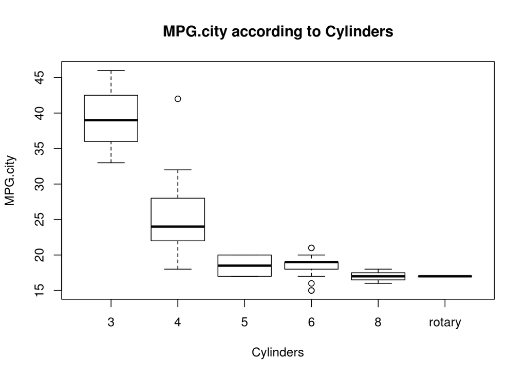

```r
boxplot(Cars93[, "MPG.city"] ~ Cars93[, "Cylinders"],
        main="MPG.city according to Cylinders", xlab="Cylinders", ylab="MPG.city")
```

### д)

Потърсете връзка между обема на двигателите и мощността. Определете outliers, кои модели са това? Пресметнете корелацията със и без outliers. Извод?

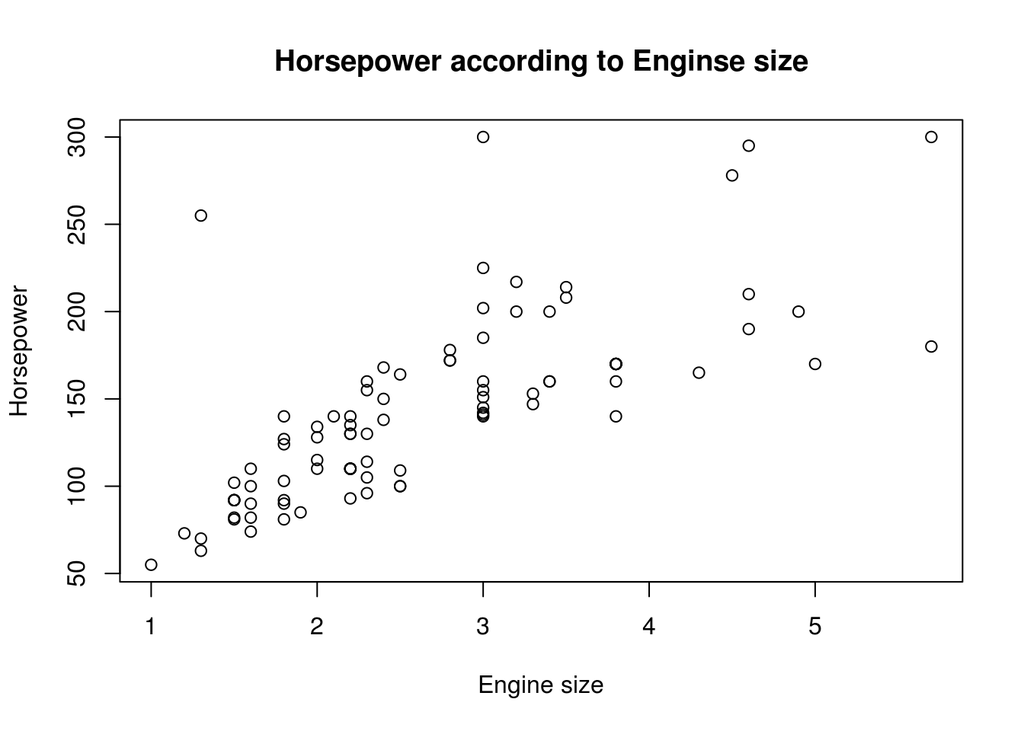

```r
plot(Cars93[, "EngineSize"], Cars93[, "Horsepower"],
      main="Horsepower according to Enginse size",
     xlab="Engine size", ylab="Horsepower")
```

```r
cor(Cars93[, "EngineSize"], Cars93[, "Horsepower"])
```

```
## [1] 0.7321197
```

Outliers разпознаваме също по графиката - тези точки, които стоят далече от правата y=x - например моделите `RX-7` и `Stealth` (двете точки горе вляво на графиката).

### е)

Представете графично цената в зависимост от броя на пътниците. Извод?

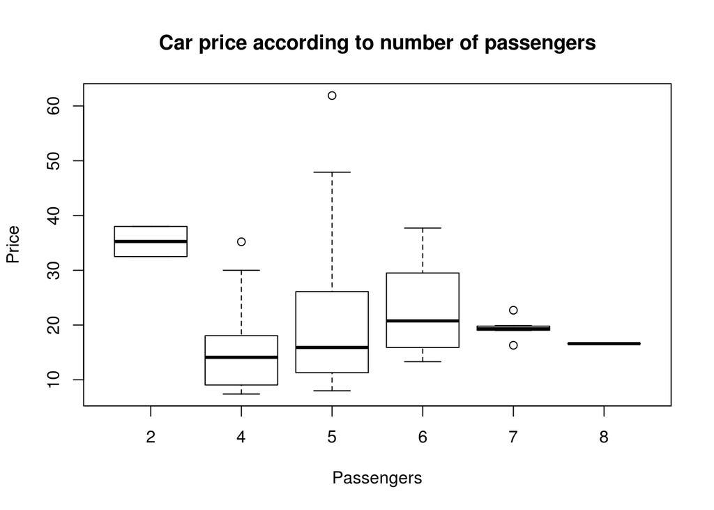

```r
boxplot(Cars93[, "Price"] ~ Cars93[, "Passengers"],
        main="Car price according to number of passengers", xlab="Passengers", ylab="Price")
```

## Зад 2.

Нека X и Y са последните две цифри от факултетния ви номер. Генерирайте 50 случайни наблюдения в равномерно разпределение в интервала [0; X + 1] и 50 случайни наблюдения, експоненциално разпределени с параметър 1 / (Y + 1).

```r
x <- 9
y <- 1
unif <- runif(50, 0, x + 1) # sample(x + 1, 50, replace = TRUE, prob = NULL)
exp <- rexp(50, 1 / (y + 1))
```

### а)

Постройте боксполот за двете извадки на една графика, направете извод.

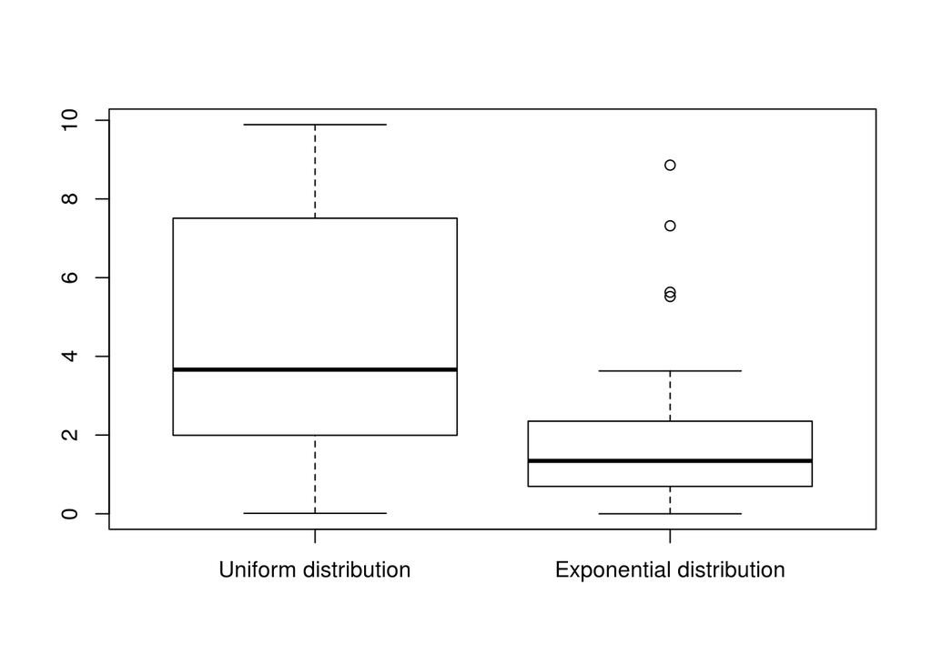

```r
x <- 9
y <- 1
boxplot(unif, exp, names=c("Uniform distribution", "Exponential distribution"))
```

При равномерното разпределение:  
* средната (очакваната) стойност е близка до средата на интервала  
* първият и четвъртият квартил са близки по големина и близки до краищата на интервала  
* обикновено няма outliers

При експоненциалното разпределение:  
* средната стойност е по-близка до началото на интервала, отколкото до средата  
* първият квартил е малък по големина, а четвъртият - голям  
* често има outliers - към края на интервала (далече от очакваната стойност)

### б)

Постройте хистограма на експоненциалните данни. На същата графика начертайте плътността, построена по данните и теоретичната плътност.

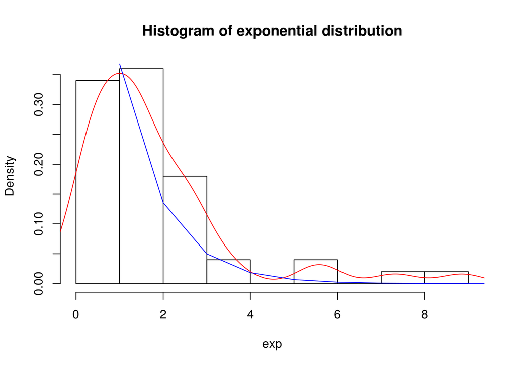

```r
x <- 9
y <- 1

hist(exp, main="Histogram of exponential distribution", freq=FALSE)
lines(density(exp), col="red") # empirical density
lines(0 : x + 1, dexp(0 : x + 1), "l", col="blue") # theoretical density
```

## Зад 3.

Нека x1, …, x4 са цели числа в интервала [0; T]. Напишете функция f(k, T, n), която по направени n на брой наблюдения пресмята емпиричната вероятност да е изпълнено x1 + 2 * x2 + 3 * x3 + x4 = k, където k е цяло число. Генерирайте случайно T в интервала [1; 10] и случайно k в интервала [10; 30] и пресметнете търсената вероятност. Направете графика на емпиричната вероятност в зависимост от броя на наблюденията.

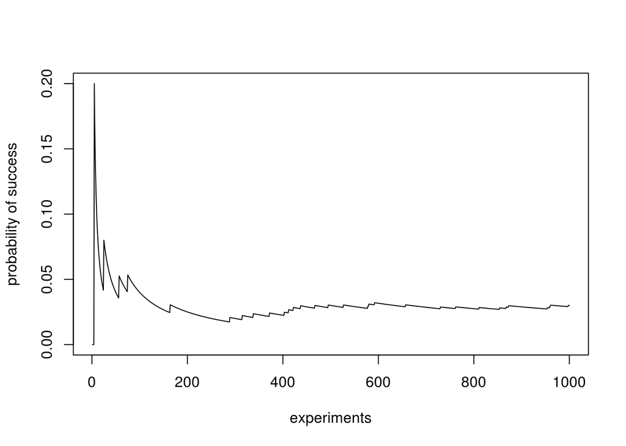

```r
f <- function(k, T, n = 1) {
  successfulExperiments <- 0

  for (i in 1 : n) {
    x <- sample(0:T, size=4, replace = TRUE, prob = NULL)

    if (x[1] + 2 * x[2] + 3 * x[3] + x[4] == k) {
      successfulExperiments = successfulExperiments + 1
    }
  }

  return (successfulExperiments / n)
}

k <- sample(10 : 30, 1, replace = TRUE, prob = NULL)
T <- sample(1 : 10, 1, replace = TRUE, prob = NULL)

n <- 1000

results <- vector()
results[1] <- 0
for (i in c(2 : n)) {
  results[i] <- results[i-1] + f(k, T)
}

for (i in c(2 : n)) {
  results[i] <- results[i] / i
}

plot(1 : n, results, "l",
     xlab="experiments", ylab="probability of success")
```